# Coursework 2 Data Science

Preamble code.

```python
import pandas as pd
import numpy as np
import matplotlib.pyplot as plt

import warnings
warnings.filterwarnings("ignore")

import torch
import torch.nn as nn
import torch.utils.data
import torch.nn.functional as F
#from IPython.core.interactiveshell import InteractiveShell
#InteractiveShell.ast_node_interactivity = "all"

from sklearn import metrics
from sklearn.preprocessing import StandardScaler
from sklearn.model_selection import StratifiedKFold
from sklearn.model_selection import GridSearchCV

from sklearn.ensemble import RandomForestClassifier
from sklearn.datasets import make_classification
from sklearn import svm
from sklearn.svm import SVC

from time import time
```

## Preliminaries

### Cleaning and Loading the data

```python
# mount my drive (faster than 'files')
from google.colab import drive
drive.mount("/content/drive")
```

```python
# change the directory to your Google Drive folder where you saved the MNIST files
train_data = pd.read_csv("/content/drive/My Drive/Datascience/train_set.csv")
test_data = pd.read_csv("/content/drive/My Drive/Datascience/test_set(1).csv")
```

```python
# check what data looks like
train_data.head()
```

|  | Unnamed: 0 | buying | maint | doors | persons | lug_boot | safety | rating |
| --- | --- | --- | --- | --- | --- | --- | --- | --- |
| 0 | 0 | low | med | 3 | 4 | small | high | good |
| 1 | 0 | vhigh | vhigh | 2 | 2 | small | low | good |
| 2 | 0 | med | med | 5more | 4 | med | high | good |
| 3 | 0 | low | med | 3 | 4 | small | high | unacc |
| 4 | 0 | vhigh | vhigh | 2 | 2 | small | low | unacc |

```python
#clean the data i.e get rid of unamed column
train1 = train_data.drop(['Unnamed: 0'],axis=1)
test1 = test_data.drop(['Unnamed: 0'],axis=1)
```

```python
#make sure there are no empty entries
train1.isnull().sum()
```

```
buying      0
maint       0
doors       0
persons     0
lug_boot    0
safety      0
rating      0
dtype: int64
```

```python
#see different catergories for each desciptor
print(train1['buying'].unique())
print(train1['maint'].unique())
print(train1['doors'].unique())
print(train1['persons'].unique())
print(train1['lug_boot'].unique())
print(train1['safety'].unique())
print(train1['rating'].unique())
```

```
['low' 'vhigh' 'med' 'high']
['med' 'vhigh' 'low' 'high']
['3' '2' '5more' '4']
['4' '2' 'more']
['small' 'med' 'big']
['high' 'low' 'med']
['good' 'unacc' 'vgood' 'acc']
```

```python
#convert them into numeriacl data, could have been efficent but this ensures data is tailored (e.g could have used a label encoder or onehotcoder)
train2=train1.replace({'buying': ('low', 'vhigh', 'med', 'high')},{'buying': (0 , 3, 1,2)})
train2=train2.replace({'maint': ('med' ,'vhigh', 'low' ,'high')},{'maint': ( 1, 3, 0,2)})
train2=train2.replace({'doors': ('3' ,'2', '5more' ,'4')},{'doors': ( 1, 0, 3,2)})
train2=train2.replace({'persons': ('4', '2' ,'more')},{'persons': (1,0,2)})
train2=train2.replace({'lug_boot': ('small' ,'med' ,'big')},{'lug_boot': (0,1,2)})
train2=train2.replace({'safety': ('high' ,'low', 'med')},{'safety': (2,0,1)})
train3=train2.replace({'rating': ('good' ,'unacc', 'vgood' ,'acc')},{'rating': (2,0,3,1)})
```

```python
#same as above but for test data
test2=test1.replace({'buying': ('low', 'vhigh', 'med', 'high')},{'buying': (0 , 3, 1,2)})
test2=test2.replace({'maint': ('med' ,'vhigh', 'low' ,'high')},{'maint': ( 1, 3, 0,2)})
test2=test2.replace({'doors': ('3' ,'2', '5more' ,'4')},{'doors': ( 1, 0, 3,2)})
test2=test2.replace({'persons': ('4', '2' ,'more')},{'persons': (1,0,2)})
test2=test2.replace({'lug_boot': ('small' ,'med' ,'big')},{'lug_boot': (0,1,2)})
test2=test2.replace({'safety': ('high' ,'low', 'med')},{'safety': (2,0,1)})
test3=test2.replace({'rating': ('good' ,'unacc', 'vgood' ,'acc')},{'rating': (2,0,3,1)})
```

```python
#see what data looks like
train3.head()
```

|  | buying | maint | doors | persons | lug_boot | safety | rating |
| --- | --- | --- | --- | --- | --- | --- | --- |
| 0 | 0 | 1 | 1 | 1 | 0 | 2 | 2 |
| 1 | 3 | 3 | 0 | 0 | 0 | 0 | 2 |
| 2 | 1 | 1 | 3 | 1 | 1 | 2 | 2 |
| 3 | 0 | 1 | 1 | 1 | 0 | 2 | 0 |
| 4 | 3 | 3 | 0 | 0 | 0 | 0 | 0 |

### Balancing the data

The following code balances the data sets, by over sampling.

```python
# class count
count_0, count_1, count_2, count_3 = train3.rating.value_counts()

# Divide by class
df_0 = train3[train3['rating'] == 0]
df_1 = train3[train3['rating'] == 1]
df_2 = train3[train3['rating'] == 2]
df_3 = train3[train3['rating'] == 3]
```

number of classifications of each type

```python
# see balance
('good' ,'unacc', 'vgood' ,'acc')
print(' unacc=',count_0,'  acc=' ,count_1, '  good= ' ,count_2, 'vgood=  ',count_3)
```

```
 unacc= 1405   acc= 871   good=  861 vgood=   851
```

As we can see 'unacceptable' is the most frequent rating in the data with 1405 entries, all the other ratings have around the 860 mark. You can either undersample or oversample, in this case we over sample as I think it always better to have data points to train the model on. So by bootstrapping we form the new data set make them all of size 1405. In this project it doesn't matter if we over or under sample as the classes roughly have same number of classifications.

```python
# bootstrapping
df_0_over = df_0.sample(count_0, replace=True).reset_index().drop(columns=['index'])
df_1_over = df_1.sample(count_0, replace=True).reset_index().drop(columns=['index'])
df_2_over = df_2.sample(count_0, replace=True).reset_index().drop(columns=['index'])
df_3_over = df_3.sample(count_0, replace=True).reset_index().drop(columns=['index'])
```

```python
# shows how acceptable rating has been resampled
df_3_over
```

|  | buying | maint | doors | persons | lug_boot | safety | rating |
| --- | --- | --- | --- | --- | --- | --- | --- |
| 0 | 0 | 1 | 0 | 2 | 1 | 2 | 3 |
| 1 | 0 | 1 | 2 | 1 | 1 | 2 | 3 |
| 2 | 0 | 0 | 2 | 2 | 1 | 1 | 3 |
| 3 | 0 | 1 | 2 | 2 | 2 | 1 | 3 |
| 4 | 0 | 3 | 2 | 1 | 0 | 2 | 3 |
| ... | ... | ... | ... | ... | ... | ... | ... |
| 1400 | 0 | 1 | 0 | 2 | 2 | 1 | 3 |
| 1401 | 0 | 0 | 2 | 2 | 0 | 2 | 3 |
| 1402 | 0 | 1 | 0 | 1 | 2 | 1 | 3 |
| 1403 | 1 | 0 | 1 | 2 | 1 | 2 | 3 |
| 1404 | 1 | 1 | 3 | 1 | 2 | 2 | 3 |

1405 rows × 7 columns

```python
# see balance of oversampled data
print(len(df_0_over), len(df_1_over), len(df_2_over), len(df_3_over))
```

```
1405 1405 1405 1405
```

```python
# concatenating all classes again to make one data set with all the data in
train4 = pd.concat([df_0_over, df_1_over, df_2_over, df_3_over])
```

### Standardising the Data

We need to standardise the data, otherwise when we use techniques like gradient descent optimisation or ascent-based optimization , certain weights will update faster than others. When we are training the models it is ideal for all descriptors to have an equal effect on the model. Also many machine learning algorithms require that the input data has been standardised, to work effectively. We also need to use different standardising model, to standardise the test set.

```python
#creates Standard model for training data
scaler_train=StandardScaler()
scaler_train.fit(train4)
```

```
StandardScaler(copy=True, with_mean=True, with_std=True)
```

We are assuming that we have enough data points that test data and training datas have similar mean and varience. So we can transform test data with training transformation.

```python
#following code standerdises the training and test data
train_scaled=scaler_train.transform(train4)
#fit test data with scalar transform of training data
test_scaled=scaler_train.transform(test3)
#turn data back into a data frame
train_scaled1 = pd.DataFrame(train_scaled,columns=['buying','maint'	,'doors',	'persons'	,'lug_boot',	'safety',	'rating'])
test_scaled1 = pd.DataFrame(test_scaled,columns=['buying','maint'	,'doors',	'persons'	,'lug_boot',	'safety',	'rating'])
#drops rating
train_clean_stand=train_scaled1.drop(['rating'],axis=1)
test_clean_stand=test_scaled1.drop(['rating'],axis=1)
#shows what training data looks like
train_clean_stand.head()
```

|  | buying | maint | doors | persons | lug_boot | safety |
| --- | --- | --- | --- | --- | --- | --- |
| 0 | 1.522473 | 1.754774 | -0.589361 | -1.869812 | -1.456977 | 0.838640 |
| 1 | 1.522473 | 1.754774 | 1.284590 | -0.437962 | -1.456977 | -1.911962 |
| 2 | -0.159685 | -0.155138 | -0.589361 | -0.437962 | 1.113083 | 0.838640 |
| 3 | -1.000765 | -0.155138 | -0.589361 | 0.993887 | -0.171947 | 0.838640 |
| 4 | -1.000765 | -1.110094 | -1.526336 | 0.993887 | -1.456977 | 0.838640 |

```python
#makes new dataframes for ratings in classification for test and training data
train_rating_class=pd.DataFrame({'rating': train_data['rating']})
test_rating_class=pd.DataFrame({'rating': test_data['rating']})
#shows train_rating_class
train_rating_class.head()
```

|  | rating |
| --- | --- |
| 0 | good |
| 1 | good |
| 2 | good |
| 3 | unacc |
| 4 | unacc |

```python
#makes new dataframes for ratings in numerical form for test and training data
train_rating_num=pd.DataFrame({'rating': train4['rating']})
test_rating_num=pd.DataFrame({'rating': test3['rating']})
#shows train_rating_num
train_rating_num.head()
```

|  | rating |
| --- | --- |
| 0 | 0 |
| 1 | 0 |
| 2 | 0 |
| 3 | 0 |
| 4 | 0 |

## 1.0 Random Forest Classifier

```python
#creates 5 splits of data which are stratified i.e equal number of classes in a sample
skf = StratifiedKFold(n_splits=5, shuffle=True)
skf.get_n_splits(train_clean_stand, train_rating_num)
```

```
5
```

The following code trains a RF classifier (with 100 tress, max depth of 5, and max features of 4 and bootstraping) over the training data of fold calculating the data over the folds. It then outputs correctly classified percentage error and inbuilt mean accuracy in a list for the validation set on each fold.

```python
#set up accuracys lists
accuracy=[]
mean_accuracy=[]

#fit the model over folds
for train_index, test_index in skf.split(train_clean_stand, train_rating_num):

  # split each fold into training and test
  X_train, X_test = train_clean_stand.iloc[train_index], train_clean_stand.iloc[test_index]
  Y_train, Y_test = train_rating_num.iloc[train_index], train_rating_num.iloc[test_index]
  #make the model and train it
  clf = RandomForestClassifier(n_estimators=100, max_depth=5 ,random_state=0,max_features=4,bootstrap=True)
  clf.fit(X_train,Y_train)
  #predict test data
  yhat_rating=clf.predict(X_test)
  #calulates accuracy score using metric
  accuracy.append(metrics.accuracy_score(yhat_rating,Y_test)*100)
  #calculates mean accuracy percentage using inbuilt method
  mean_accuracy.append(clf.score(X_test,Y_test)*100)


print('Accuracy:', accuracy )
print('In built Accuracy Function:' ,mean_accuracy)
print('Mean Accuracy:',np.mean(accuracy))
```

```
Accuracy: [37.455516014234874, 39.05693950177936, 39.94661921708185, 40.30249110320285, 41.370106761565836]
In built Accuracy Function: [37.455516014234874, 39.05693950177936, 39.94661921708185, 40.30249110320285, 41.370106761565836]
Mean Accuracy: 39.62633451957295
```

The in built function gives the same results as specific accuracy function, so will just use in built function from now on. But after an initial inspection we can see the accuracy is not great, hopefully this will improve once we optimise the hyper parameters.

### 1.1 Optimising over number of trees

Uses the same folds of the data as above for good comparison. This code calculates the accuracy of the model for varying levels of number of trees.

```python
#set up accuracy vectors
accuracy_mean_vector=[]
accuracy_max_vector=[]
accuracy_min_vector=[]
#values of numbers of decision tree to iterate over
n_trees=[10,20,30,40,50,60,70,80,90,100,150,200,250,300,400,500,750,1000,1250,1500,2000]
for i in range(len(n_trees)):
  #reset accuracy vector
  accuracy=[]
  #fit the model over folds
  for train_index, test_index in skf.split(train_clean_stand, train_rating_num):
     # split each fold into training and test
    X_train, X_test = train_clean_stand.iloc[train_index], train_clean_stand.iloc[test_index]
    Y_train, Y_test = train_rating_num.iloc[train_index], train_rating_num.iloc[test_index]
    #make the model and train it
    clf1 = RandomForestClassifier(n_estimators=n_trees[i], max_depth=5 ,random_state=0,max_features=4,bootstrap=True)
    clf1.fit(X_train,Y_train)
    #calculates mean accuracy percentage using inbuilt method
    accuracy.append(clf1.score(X_test,Y_test)*100)
    #delete model
    del clf1
  accuracy_mean_vector.append(np.mean(accuracy))
  accuracy_max_vector.append(np.max(accuracy))
  accuracy_min_vector.append(np.min(accuracy))
```

The following code generates the graph for comparing number of trees vs accuracy. With the vectors being printed and optimum number of trees.

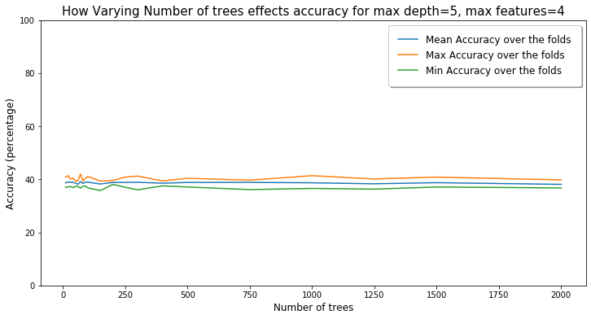

```
mean accuracy: [38.64768683274021, 38.95017793594306, 38.91459074733096, 38.82562277580071, 38.57651245551602, 38.096085409252666, 39.12811387900356, 38.416370106761576, 38.95017793594306, 38.896797153024906, 38.23843416370107, 38.82562277580071, 38.82562277580071, 38.87900355871886, 38.540925266903…
max accuracy over folds: [40.83629893238434, 41.370106761565836, 40.12455516014235, 40.480427046263344, 39.32384341637011, 39.50177935943061, 41.99288256227758, 39.32384341637011, 40.39145907473309, 41.10320284697509, 39.32384341637011, 39.59074733096085, 40.83629893238434, 41.19217081850534, 39.412…
min accuracy over folds: [36.92170818505338, 37.18861209964413, 37.27758007117438, 36.83274021352313, 37.36654804270463, 37.27758007117438, 36.654804270462634, 37.36654804270463, 37.455516014234874, 36.743772241992886, 35.76512455516014, 38.07829181494662, 37.01067615658363, 36.032028469750884, 37.5…
optimum number of tress: 70
max accuracy:  39.12811387900356
```

```python
#plots a scatter graph
plt.figure(figsize=(12, 6))
plt.plot(n_trees,accuracy_mean_vector,label="Mean Accuracy over the folds")
plt.plot(n_trees,accuracy_max_vector,label="Max Accuracy over the folds")
plt.plot(n_trees,accuracy_min_vector,label="Min Accuracy over the folds")

#labels axis
plt.xlabel('Number of trees',size=12)
plt.ylabel('Accuracy (percentage)',size=12)
#sets y axis limits
plt.ylim(0,100)
#gives title
plt.title('How Varying Number of trees effects accuracy for max depth=5, max features=4',size=15)
#gives legend
plt.legend(loc="upper right",fontsize=12,fancybox=True, framealpha=1, shadow=True, borderpad=1)
plt.show()

print('mean accuracy:',accuracy_mean_vector)
print('max accuracy over folds:',accuracy_max_vector)
print('min accuracy over folds:',accuracy_min_vector)
print('optimum number of tress:',n_trees[accuracy_mean_vector.index(max(accuracy_mean_vector))])
print('max accuracy: ',max(accuracy_mean_vector))
```

As we can there is a slight varation when then number of tree is less then a 100, but otherwise accuracy is pretty bad, but very consistant over the folds. The difference between the min and max accuracy being very small, defiantly suggests the model is not overfitting.

```python
#set up accuracy vectors
accuracy_mean_vector2=[]
accuracy_max_vector2=[]
accuracy_min_vector2=[]
#values of numbers of decision tree to iterate over
n_trees1=range(1,90)
for i in range(len(n_trees1)):
  #reset accuracy vector
  accuracy.clear()
  accuracy=[]
  #fit the model over folds
  for train_index, test_index in skf.split(train_clean_stand, train_rating_num):
     # split each fold into training and test
    X_train, X_test = train_clean_stand.iloc[train_index], train_clean_stand.iloc[test_index]
    Y_train, Y_test = train_rating_num.iloc[train_index], train_rating_num.iloc[test_index]
    #make the model and train it
    clf2 = RandomForestClassifier(n_estimators=n_trees1[i], max_depth=5 ,random_state=0,max_features=4,bootstrap=True)
    clf2.fit(X_train,Y_train)
    #calculates mean accuracy percentage using inbuilt method
    accuracy.append(clf2.score(X_test,Y_test)*100)
  #delete model
  del clf2
  accuracy_mean_vector2.append(np.mean(accuracy))
  accuracy_max_vector2.append(np.max(accuracy))
  accuracy_min_vector2.append(np.min(accuracy))
```

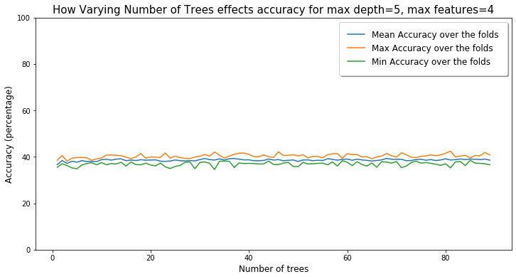

```
mean accuracy: [36.654804270462634, 38.39857651245552, 37.15302491103203, 38.11387900355872, 37.68683274021352, 38.345195729537366, 38.007117437722414, 38.00711743772242, 37.93594306049822, 38.77224199288256, 38.91459074733096, 38.594306049822066, 39.00355871886121, 39.12811387900355, 38.32740213523…
max accuracy over folds: [38.52313167259786, 40.569395017793596, 38.07829181494662, 39.412811387900355, 39.679715302491104, 39.679715302491104, 39.59074733096085, 38.52313167259786, 39.05693950177936, 39.50177935943061, 40.74733096085409, 40.74733096085409, 40.65836298932384, 40.480427046263344, 39.…
min accuracy over folds: [35.49822064056939, 37.01067615658363, 36.20996441281139, 35.231316725978644, 34.87544483985765, 36.47686832740214, 37.09964412811388, 37.455516014234874, 36.56583629893239, 37.544483985765126, 36.56583629893239, 37.09964412811388, 36.92170818505338, 37.63345195729537, 36.03…
optimum number of tress 68
max accuracy:  39.306049822064054
```

```python
#plots a scatter graph
plt.figure(figsize=(12, 6))
plt.plot(n_trees1,accuracy_mean_vector2,label="Mean Accuracy over the folds")
plt.plot(n_trees1,accuracy_max_vector2,label="Max Accuracy over the folds")
plt.plot(n_trees1,accuracy_min_vector2,label="Min Accuracy over the folds")
#labels axis
plt.xlabel('Number of trees',size=12)
plt.ylabel('Accuracy (percentage)',size=12)
#sets y axis limits
plt.ylim(0,100)
#gives title
plt.title('How Varying Number of Trees effects accuracy for max depth=5, max features=4',size=15)
#gives legend
plt.legend(loc="upper right",fontsize=12,fancybox=True, framealpha=1, shadow=True, borderpad=1)
plt.show()

#relevnant data
print('mean accuracy:',accuracy_mean_vector2)
print('max accuracy over folds:',accuracy_max_vector2)
print('min accuracy over folds:',accuracy_min_vector2)
print('optimum number of tress',n_trees1[accuracy_mean_vector2.index(max(accuracy_mean_vector2))])
print('max accuracy: ',max(accuracy_mean_vector2))
```

Again similar results for varying very large number of trees, but not as consistant, with number of tress having little effect the outcome of the model. We would have expected for small number of trees values the model to not be very good, but we only get 1.5-2% improvement as number of trees increases. This is an unexpected result, as usually you get a better model but at more computuational expense. This suggests that maybe the model or the data or predictors themselves are not approrioate.

### 1.2 Varying the depth of the tree

Code which varyies the depth of trees.

```python
#set up accuracy vectors
accuracy_mean_vector3=[]
accuracy_max_vector3=[]
accuracy_min_vector3=[]
#values of numbers of decision tree to iterate over
max_depth1=[1,2,3,4,5,6,7,8,9,10,12,15,20,25,30]
for i in range(len(max_depth1)):
  #reset accuracy vector
  accuracy=[]
  accuracy.clear()
  accuracy=[]
  #fit the model over folds
  for train_index, test_index in skf.split(train_clean_stand, train_rating_num):
     # split each fold into training and test
    X_train, X_test = train_clean_stand.iloc[train_index], train_clean_stand.iloc[test_index]
    Y_train, Y_test = train_rating_num.iloc[train_index], train_rating_num.iloc[test_index]
    #make the model and train it
    clf3 = RandomForestClassifier(n_estimators=39, max_depth=max_depth1[i] ,random_state=0,max_features=4,bootstrap=True)
    clf3.fit(X_train,Y_train)
    #calculates mean accuracy percentage using inbuilt method
    accuracy.append(clf3.score(X_test,Y_test)*100)
  #delete model
  del clf3
  accuracy_mean_vector3.append(np.mean(accuracy))
  accuracy_max_vector3.append(np.max(accuracy))
  accuracy_min_vector3.append(np.min(accuracy))
```

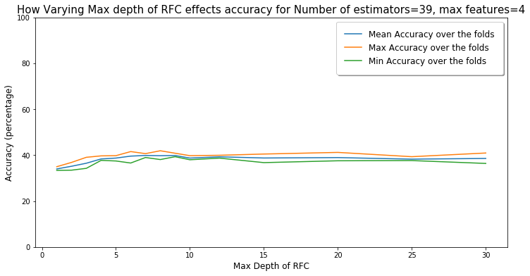

```
mean accuracy: [33.98576512455516, 35.16014234875445, 36.47686832740213, 38.345195729537366, 38.718861209964416, 39.5729537366548, 39.8576512455516, 39.75088967971531, 39.83985765124555, 38.718861209964416, 39.27046263345196, 38.754448398576514, 38.93238434163701, 38.256227758007114, 38.558718861209…
max accuracy over folds: [34.9644128113879, 36.83274021352313, 39.05693950177936, 39.679715302491104, 39.768683274021356, 41.54804270462634, 40.65836298932384, 41.903914590747334, 40.83629893238434, 39.768683274021356, 39.94661921708185, 40.480427046263344, 41.19217081850534, 39.32384341637011, 40.9…
min accuracy over folds: [33.362989323843415, 33.45195729537366, 34.25266903914591, 37.72241992882562, 37.455516014234874, 36.56583629893239, 38.967971530249116, 38.07829181494662, 39.32384341637011, 37.98932384341637, 38.70106761565836, 36.743772241992886, 37.544483985765126, 37.63345195729537, 36.…
optimum Depth 7
```

```python
#plots a scatter graph
plt.figure(figsize=(12, 6))
plt.plot(max_depth1,accuracy_mean_vector3,label="Mean Accuracy over the folds")
plt.plot(max_depth1,accuracy_max_vector3,label="Max Accuracy over the folds")
plt.plot(max_depth1,accuracy_min_vector3,label="Min Accuracy over the folds")
#labels axis
plt.xlabel('Max Depth of RFC',size=12)
plt.ylabel('Accuracy (percentage)',size=12)
#sets y axis limits
plt.ylim(0,100)
#gives title
plt.title('How Varying Max depth of RFC effects accuracy for Number of estimators=39, max features=4',size=15)
#gives legend
plt.legend(loc="upper right",fontsize=12,fancybox=True, framealpha=1, shadow=True, borderpad=1)
plt.show()

print('mean accuracy:',accuracy_mean_vector3)
print('max accuracy over folds:',accuracy_max_vector3)
print('min accuracy over folds:',accuracy_min_vector3)
print('optimum Depth',max_depth1[accuracy_mean_vector3.index(max(accuracy_mean_vector3))])
```

Varying the depth does seem to effect the model, with the model being consisent on each fold and not overfitting (shown by small gap between max and min accuracy). The max depth represent the depth of each tree. So the greater the depth, the greater the number of splits. When we have more splits, it captures more information about the data. In this situation we have 6 predictors, which is why a depth of 7 is hitting the sweet spot, as a depth of less then this doesn't capture the information of the data aswell.

### 1.3 Varying max features

```python
#set up accuracy vectors
accuracy_mean_vector4=[]
accuracy_max_vector4=[]
accuracy_min_vector4=[]
#values of numbers of decision tree to iterate over
max_features1=[1,2,3,4,5,6]
for i in range(len(max_features1)):
  #reset accuracy vector
  accuracy=[]
  accuracy.clear()
  accuracy=[]
  #fit the model over folds
  for train_index, test_index in skf.split(train_clean_stand, train_rating_num):
     # split each fold into training and test
    X_train, X_test = train_clean_stand.iloc[train_index], train_clean_stand.iloc[test_index]
    Y_train, Y_test = train_rating_num.iloc[train_index], train_rating_num.iloc[test_index]
    #make the model and train it
    clf4 = RandomForestClassifier(n_estimators=39, max_depth=7 ,random_state=0,max_features=max_features1[i],bootstrap=True)
    clf4.fit(X_train,Y_train)
    #calculates mean accuracy percentage using inbuilt method
    accuracy.append(clf4.score(X_test,Y_test)*100)
  #delete model
  accuracy_mean_vector4.append(np.mean(accuracy))
  accuracy_max_vector4.append(np.max(accuracy))
  accuracy_min_vector4.append(np.min(accuracy))
```

[figure not shown]

```
mean accuracy: [39.25266903914591, 40.177935943060504, 39.804270462633454, 40.12455516014235, 40.0, 39.804270462633454]
max accuracy over folds: [40.83629893238434, 41.81494661921708, 40.65836298932384, 41.72597864768684, 41.45907473309609, 41.014234875444835]
min accuracy over folds: [37.72241992882562, 39.23487544483986, 38.70106761565836, 38.07829181494662, 38.43416370106761, 38.256227758007114]
optimum Depth 2
```

```python
#plots a scatter graph
plt.figure(figsize=(12, 6))
plt.plot(max_features1,accuracy_mean_vector4,label="Mean Accuracy over the folds")
plt.plot(max_features1,accuracy_max_vector4,label="Max Accuracy over the folds")
plt.plot(max_features1,accuracy_min_vector4,label="Min Accuracy over the folds")
#labels axis
plt.xlabel('Max Features of RFC',size=12)
plt.ylabel('Accuracy (percentage)',size=12)
#sets y axis limits
plt.ylim(0,100)
#gives title
plt.title('How Varying Max Features of RFC effects accuracy for Number of estimators=80, max features=4',size=15)
#gives legend
plt.legend(loc="upper right",fontsize=12,fancybox=True, framealpha=1, shadow=True, borderpad=1)
plt.show()

print('mean accuracy:',accuracy_mean_vector4)
print('max accuracy over folds:',accuracy_max_vector4)
print('min accuracy over folds:',accuracy_min_vector4)
print('optimum Depth',max_features1[accuracy_mean_vector4.index(max(accuracy_mean_vector4))])
```

Varying the max features does not seem to really effect the model at all. We would expect features/3 to give good results for the classification problem, in this case it is true. It is a little surprising max features does not have more of an effect considering feature importances are quite varied for the predictors(tested on all training data with no dependence on max feature), for example meaning when exclude buying feature should effect quality of the model. However it appears this is not the case. If the number of features was far greater then 6 then we would expect this hyperparameter to have more of an effect.

```python
#fit model on all training data with max features=6 to see feature importance
clf = RandomForestClassifier(n_estimators=39, max_depth=7 ,random_state=0,max_features=6,bootstrap=True)
clf.fit(train_clean_stand, train_rating_num)

#shows how important the features are
pd.DataFrame({'feature': list(train_clean_stand.columns),
                   'importance': clf.feature_importances_}).\
                    sort_values('importance', ascending = False)
```

|  | feature | importance |
| --- | --- | --- |
| 0 | buying | 0.425207 |
| 5 | safety | 0.179022 |
| 3 | persons | 0.156223 |
| 1 | maint | 0.097664 |
| 2 | doors | 0.071940 |
| 4 | lug_boot | 0.069944 |

### 1.4 The best hyperparameters for RFC

The code below uses grid search, giving an idea for the best hyperparameters, but it is not the best relative to the k fold cross validation accuracy but accuracy acroos all the training data.

```python
n_trees2=[70,75,80,90,100,125,150,200,750]
max_features2=[2,3,4,5]
max_depth2=[1,2,3,4,5,6,7,8,9,10]
param_grid = dict(n_estimators=n_trees2,max_features=max_features2,max_depth=max_depth2)
clf5=RandomForestClassifier(random_state=0,bootstrap=True)
grid = GridSearchCV(clf5, scoring='accuracy', param_grid=param_grid, cv=skf)
grid.fit(train_clean_stand, train_rating_num)

clf = RandomForestClassifier(n_estimators=39, max_depth=7 ,random_state=0,max_features=6,bootstrap=True)
clf.fit(train_clean_stand, train_rating_num)

print("The best parameters are %s with a score of %0.8f"
      % (grid.best_params_, grid.best_score_))
```

```
The best parameters are {'max_depth': 7, 'max_features': 3, 'n_estimators': 750} with a score of 0.40462633
```

This code loops over over the parameters optimising it across the mean accuracy cross validating across the k folds.

```python
#values of hyperparameters of decision tree to iterate over
n_trees2=[6,8,10,12,14,16,18,20,22,24,26,28,30,32,34,36,38,40,45,50,55,60,65,70,75,80,90,100,200,750]
max_features2=[2,3,4,5,6]
max_depth2=[3,4,5,6,7,8]
#set best accuracy
best_accuracy=0
#loop through number of trees
for k in range(len(n_trees2)):
  #loop through max features
  for j in range(len(max_features2)):
    #loop through depth
    for i in range(len(max_depth2)):
      #reset accuracy vector
      accuracy=0
      #fit the model over folds
      for train_index, test_index in skf.split(train_clean_stand, train_rating_num):
        # split each fold into training and test
        X_train, X_test = train_clean_stand.iloc[train_index], train_clean_stand.iloc[test_index]
        Y_train, Y_test = train_rating_num.iloc[train_index], train_rating_num.iloc[test_index]
        #make the model and train it
        clf4 = RandomForestClassifier(n_estimators=n_trees2[k], max_depth=max_depth2[i] ,random_state=0,max_features=max_features2[j],bootstrap=True)
        clf4.fit(X_train,Y_train)
        #calculates mean accuracy percentage using inbuilt method
        accuracy=clf4.score(X_test,Y_test)*20+accuracy
        #delete model
      del clf4
      if accuracy>best_accuracy:
        #updates best accuracy
        best_accuracy=accuracy
        #finds position of best parameters
        ibest=i
        jbest=j
        kbest=k
print("best accuracy:",best_accuracy)
print("Optimum parameters: Number of trees=",n_trees2[kbest],", Max features = " ,max_features2[jbest],", Max Depth = ",max_depth2[ibest])
```

```
best accuracy: 40.80071174377225
Optimum parameters: Number of trees= 100 , Max features =  4 , Max Depth =  8
```

So the optimum hyperparameters is Number of trees= 100 , Max features = 4 , Max Depth = 8, the code below makes this model. But varying them does not effect the end results as by optimising the hyperparameters you only really get a 1-3% increase in accuracy in the cross validations, which is not very much. It is surprising that max features is 4 as it more often than not 2, but the difference between 2 and 4 Max features is negligible. The depth of the tree effects the model the most, but still not by much.

```python
#fit the best model
RFC_best = RandomForestClassifier(n_estimators=100, max_depth=8 ,random_state=0,max_features=4,bootstrap=True)
RFC_best.fit(train_clean_stand, train_rating_num)
```

```
RandomForestClassifier(bootstrap=True, class_weight=None, criterion='gini',
                       max_depth=8, max_features=4, max_leaf_nodes=None,
                       min_impurity_decrease=0.0, min_impurity_split=None,
                       min_samples_leaf=1, min_samples_split=2,
                       min_weight_fraction_leaf=0.0, n_estimators=100,
                       n_jobs=None, oob_score=False, random_state=0, verbose=0,
                       warm_start=False)
```

```python
confusion_matrix = pd.crosstab(y_test, y_pred, rownames=['Actual'], colnames=['Predicted'])
sn.heatmap(confusion_matrix, annot=True)

from sklearn.metrics import classification_report, confusion_matrix, accuracy_score

print(confusion_matrix(y_test,y_pred))
print(classification_report(y_test,y_pred))
print(accuracy_score(y_test, y_pred))
```

[output not shown]

## SVM

2.1 Best SVM with linear kernal.

The following code does an exhaustive grid search to find a rough idea of the optimum hyperparameter values. But optimises over the training daata not the k-folds.

```python
#values we optimise over
Cs = [0.001, 0.01, 0.1, 1, 10]
gammas = [0.0001,0.001, 0.01, 0.1, 1]
#set up a gris diction to optimise hyper parameters over
param_grid = dict(gamma=gammas, C=Cs)
#create SVM models with a linear kernel
svc = svm.SVC(kernel='linear')
#do an exhaustive search over the grid optimising over accuracy
grid = GridSearchCV(svc, scoring='accuracy',param_grid=param_grid, cv=skf)
#fit to training data
grid.fit(train_clean_stand, train_rating_num)

print("The best parameters are %s with a score of %0.8f"
      % (grid.best_params_, grid.best_score_))
```

```
The best parameters are {'C': 1, 'gamma': 0.0001} with a score of 0.33825623
```

The following code produces data so we can explore how changing gamma and c effects the model, giving us more information about the accuracy over the folds.

```python
#code to vary gamma (probably code have wriiten this in a loop but didn't want to mess around with indexing)

#set up accuracy vectors for different cs
accuracy_mean_vector1=[]
accuracy_mean_vector2=[]
accuracy_mean_vector3=[]
accuracy_mean_vector4=[]
accuracy_mean_vector5=[]
#values of gamma to be varied
gammas = [0.0001,0.0002,0.0004,0.0006,0.0008,0.001,0.0012,0.0014,0.0016,0.0018,0.0020,0.0025,0.0030]
#iterate over c=0.1
for i in range(len(gammas)):
  #reset accuracy vector
  accuracy=[]
  accuracy.clear()
  accuracy=[]
   #fit the model over folds
  for train_index, test_index in skf.split(train_clean_stand, train_rating_num):
        # split each fold into training and test
        X_train, X_test = train_clean_stand.iloc[train_index], train_clean_stand.iloc[test_index]
        Y_train, Y_test = train_rating_num.iloc[train_index], train_rating_num.iloc[test_index]
    #make the model and train it
        svc = svm.SVC(kernel='linear',gamma=0.0005, C=0.1)
        svc.fit(X_train,Y_train)
    #calculates mean accuracy percentage using inbuilt method
        accuracy.append(svc.score(X_test,Y_test)*100)
         # delete model
  del svc
  accuracy_mean_vector1.append(np.mean(accuracy))
#itertae over c=0.5
for i in range(len(gammas)):
  #reset accuracy vector
  accuracy=[]
  accuracy.clear()
  accuracy=[]
   #fit the model over folds
  for train_index, test_index in skf.split(train_clean_stand, train_rating_num):
        # split each fold into training and test
        X_train, X_test = train_clean_stand.iloc[train_index], train_clean_stand.iloc[test_index]
        Y_train, Y_test = train_rating_num.iloc[train_index], train_rating_num.iloc[test_index]
    #make the model and train it
        svc = svm.SVC(kernel='linear',gamma=0.0005, C=0.5)
        svc.fit(X_train,Y_train)
    #calculates mean accuracy percentage using inbuilt method
        accuracy.append(svc.score(X_test,Y_test)*100)
         # delete model
  del svc
  accuracy_mean_vector2.append(np.mean(accuracy))

#iterate over c=1
for i in range(len(gammas)):
  #reset accuracy vector
  accuracy=[]
  accuracy.clear()
  accuracy=[]
   #fit the model over folds
  for train_index, test_index in skf.split(train_clean_stand, train_rating_num):
        # split each fold into training and test
        X_train, X_test = train_clean_stand.iloc[train_index], train_clean_stand.iloc[test_index]
        Y_train, Y_test = train_rating_num.iloc[train_index], train_rating_num.iloc[test_index]
    #make the model and train it
        svc = svm.SVC(kernel='linear',gamma=gammas[i], C=1)
        svc.fit(X_train,Y_train)
    #calculates mean accuracy percentage using inbuilt method
        accuracy.append(svc.score(X_test,Y_test)*100)
         # delete model
  del svc
  accuracy_mean_vector3.append(np.mean(accuracy))
#iterate over c=5
for i in range(len(gammas)):
  #reset accuracy vector
  accuracy=[]
  accuracy.clear()
  accuracy=[]
   #fit the model over folds
  for train_index, test_index in skf.split(train_clean_stand, train_rating_num):
        # split each fold into training and test
        X_train, X_test = train_clean_stand.iloc[train_index], train_clean_stand.iloc[test_index]
        Y_train, Y_test = train_rating_num.iloc[train_index], train_rating_num.iloc[test_index]
    #make the model and train it
        svc = svm.SVC(kernel='linear',gamma=gammas[i], C=5)
        svc.fit(X_train,Y_train)
    #calculates mean accuracy percentage using inbuilt method
        accuracy.append(svc.score(X_test,Y_test)*100)
         # delete model
  del svc
  accuracy_mean_vector4.append(np.mean(accuracy))
#for c=10
for i in range(len(gammas)):
  #reset accuracy vector
  accuracy=[]
  accuracy.clear()
  accuracy=[]
   #fit the model over folds
  for train_index, test_index in skf.split(train_clean_stand, train_rating_num):
        # split each fold into training and test
        X_train, X_test = train_clean_stand.iloc[train_index], train_clean_stand.iloc[test_index]
        Y_train, Y_test = train_rating_num.iloc[train_index], train_rating_num.iloc[test_index]
    #make the model and train it
        svc = svm.SVC(kernel='linear',gamma=gammas[i], C=10)
        svc.fit(X_train,Y_train)
    #calculates mean accuracy percentage using inbuilt method
        accuracy.append(svc.score(X_test,Y_test)*100)
         # delete model
  del svc
  accuracy_mean_vector5.append(np.mean(accuracy))
```

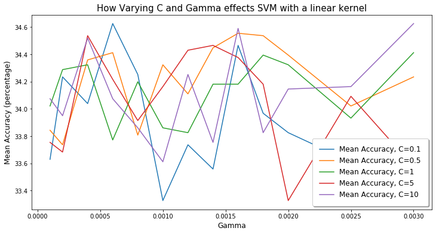

```
Optimum gamma for C=0.1 :  0.0006
Optimum gamma for C=0.5 :  0.0016
Optimum gamma for C=1 :  0.003
Optimum gamma for C=5 :  0.0004
Optimum gamma for C=10 :  0.003
```

```python
#plots a scatter graph
plt.figure(figsize=(12, 6))
plt.plot(gammas,accuracy_mean_vector1,label="Mean Accuracy, C=0.1")
plt.plot(gammas,accuracy_mean_vector2,label="Mean Accuracy, C=0.5")
plt.plot(gammas,accuracy_mean_vector3,label="Mean Accuracy, C=1")
plt.plot(gammas,accuracy_mean_vector4,label="Mean Accuracy, C=5")
plt.plot(gammas,accuracy_mean_vector5,label="Mean Accuracy, C=10")
#labels axis
plt.xlabel('Gamma',size=12)
plt.ylabel('Mean Accuracy (percentage)',size=12)
#gives title
plt.title('How Varying C and Gamma effects SVM with a linear kernel',size=15)
#gives legend
plt.legend(loc="lower right",fontsize=12,fancybox=True, framealpha=1, shadow=True, borderpad=1)
plt.show()
#code to find optimum gammas
print('Optimum gamma for C=0.1 : ',gammas[accuracy_mean_vector1.index(max(accuracy_mean_vector1))])
print('Optimum gamma for C=0.5 : ',gammas[accuracy_mean_vector2.index(max(accuracy_mean_vector2))])
print('Optimum gamma for C=1 : ',gammas[accuracy_mean_vector3.index(max(accuracy_mean_vector3))])
print('Optimum gamma for C=5 : ',gammas[accuracy_mean_vector4.index(max(accuracy_mean_vector4))])
print('Optimum gamma for C=10 : ',gammas[accuracy_mean_vector5.index(max(accuracy_mean_vector5))])
```

In theory we don't expect gamma to change the outcome for a linear kernel model, but as we see it clearly does. However it only has minor effects on the outcome of the model. In this case Gamma is very low, which means the model will have high bias and low variance, which might explain why it is only getting 34.6% accuracy, as model might just be classifing one outcome very well and occasionally some of the others. But we will look into this later on.

### 2.2 Best SVM with polynomial kernal.

The code below gives us a rough idea of hyperparameters to optimise over. We consider gamma and C less than 1, as greater then this and it takes too long to fit the model (plus 5 mins per parameter search) and they yield bad results for these parameters anyway. High gamma will give high varience which we do not want as only 4 outcome classifications. We use a polynomial of degree 6, as for more then this it is computational inefficent and not much gain, as we have only 6 predictors. So a polynomial of degree 6 should be sufficent.

```python
#values we optimise over
Cs = [0.0001,0.001, 0.01, 0.1, 1]
gammas = [0.0001,0.001, 0.01, 0.1]
#set up a gris diction to optimise hyper parameters over
param_grid = dict(gamma=gammas, C=Cs)
#create SVM models with a poly kernel of degree 6
svc = svm.SVC(kernel='poly', degree=6)
#do an exhaustive search over the grid optimising over accuracy
grid = GridSearchCV(svc, scoring='accuracy',param_grid=param_grid, cv=skf)
#fit to training data
grid.fit(train_clean_stand, train_rating_num)

print("The best parameters are %s with a score of %0.8f"
      % (grid.best_params_, grid.best_score_))
```

```
The best parameters are {'C': 1, 'gamma': 0.1} with a score of 0.33487544
```

The code below uses loops to find the best hyperparameters(c,gamma)and allows us to see how they effect the model.

```python
#code to vary gamma (probably code have wriiten this in a loop but didn't want to mess around with indexing)

#set up accuracy vectors for different cs
accuracy_mean_vector1p=[]
accuracy_mean_vector2p=[]
accuracy_mean_vector3p=[]
accuracy_mean_vector4p=[]
accuracy_mean_vector5p=[]
#values of gamma to be varied
gammas = [0.01,0.05,0.1,0.2,0.5]
#iterate over c=0.1
for i in range(len(gammas)):
  #reset accuracy vector
  accuracy=[]
  accuracy.clear()
  accuracy=[]
   #fit the model over folds
  for train_index, test_index in skf.split(train_clean_stand, train_rating_num):
        # split each fold into training and test
        X_train, X_test = train_clean_stand.iloc[train_index], train_clean_stand.iloc[test_index]
        Y_train, Y_test = train_rating_num.iloc[train_index], train_rating_num.iloc[test_index]
    #make the model and train it
        svc = svm.SVC(kernel='poly', degree=6,gamma=gammas[i],C=0.1)
        svc.fit(X_train,Y_train)
    #calculates mean accuracy percentage using inbuilt method
        accuracy.append(svc.score(X_test,Y_test)*100)
         # delete model
  del svc
  accuracy_mean_vector1p.append(np.mean(accuracy))
#itertae over c=0.5
for i in range(len(gammas)):
  #reset accuracy vector
  accuracy=[]
  accuracy.clear()
  accuracy=[]
   #fit the model over folds
  for train_index, test_index in skf.split(train_clean_stand, train_rating_num):
        # split each fold into training and test
        X_train, X_test = train_clean_stand.iloc[train_index], train_clean_stand.iloc[test_index]
        Y_train, Y_test = train_rating_num.iloc[train_index], train_rating_num.iloc[test_index]
    #make the model and train it
        svc = svm.SVC(kernel='poly', degree=6,gamma=gammas[i],C=0.5)
        svc.fit(X_train,Y_train)
    #calculates mean accuracy percentage using inbuilt method
        accuracy.append(svc.score(X_test,Y_test)*100)
         # delete model
  del svc
  accuracy_mean_vector2p.append(np.mean(accuracy))

#iterate over c=1
for i in range(len(gammas)):
  #reset accuracy vector
  accuracy=[]
  accuracy.clear()
  accuracy=[]
   #fit the model over folds
  for train_index, test_index in skf.split(train_clean_stand, train_rating_num):
        # split each fold into training and test
        X_train, X_test = train_clean_stand.iloc[train_index], train_clean_stand.iloc[test_index]
        Y_train, Y_test = train_rating_num.iloc[train_index], train_rating_num.iloc[test_index]
    #make the model and train it
        svc = svm.SVC(kernel='poly', degree=6,gamma=gammas[i],C=1)
        svc.fit(X_train,Y_train)
    #calculates mean accuracy percentage using inbuilt method
        accuracy.append(svc.score(X_test,Y_test)*100)
         # delete model
  del svc
  accuracy_mean_vector3p.append(np.mean(accuracy))
#iterate over c=5
for i in range(len(gammas)):
  #reset accuracy vector
  accuracy=[]
  accuracy.clear()
  accuracy=[]
   #fit the model over folds
  for train_index, test_index in skf.split(train_clean_stand, train_rating_num):
        # split each fold into training and test
        X_train, X_test = train_clean_stand.iloc[train_index], train_clean_stand.iloc[test_index]
        Y_train, Y_test = train_rating_num.iloc[train_index], train_rating_num.iloc[test_index]
    #make the model and train it
        svc = svm.SVC(kernel='poly', degree=6,gamma=gammas[i],C=1.5)
        svc.fit(X_train,Y_train)
    #calculates mean accuracy percentage using inbuilt method
        accuracy.append(svc.score(X_test,Y_test)*100)
         # delete model
  del svc
  accuracy_mean_vector4p.append(np.mean(accuracy))
#for c=10
for i in range(len(gammas)):
  #reset accuracy vector
  accuracy=[]
  accuracy.clear()
  accuracy=[]
   #fit the model over folds
  for train_index, test_index in skf.split(train_clean_stand, train_rating_num):
        # split each fold into training and test
        X_train, X_test = train_clean_stand.iloc[train_index], train_clean_stand.iloc[test_index]
        Y_train, Y_test = train_rating_num.iloc[train_index], train_rating_num.iloc[test_index]
    #make the model and train it
        svc = svm.SVC(kernel='poly', degree=6,gamma=gammas[i],C=2)
        svc.fit(X_train,Y_train)
    #calculates mean accuracy percentage using inbuilt method
        accuracy.append(svc.score(X_test,Y_test)*100)
         # delete model
  del svc
  accuracy_mean_vector5p.append(np.mean(accuracy))
```

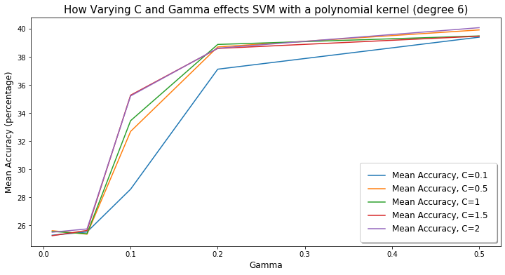

```
Optimum gamma for C=0.1 :  0.5
Optimum gamma for C=0.5 :  0.5
Optimum gamma for C=1 :  0.5
Optimum gamma for C=1.5 :  0.5
Optimum gamma for C=2 :  0.5
```

```python
#plots a scatter graph
plt.figure(figsize=(12, 6))
plt.plot(gammas,accuracy_mean_vector1p,label="Mean Accuracy, C=0.1")
plt.plot(gammas,accuracy_mean_vector2p,label="Mean Accuracy, C=0.5")
plt.plot(gammas,accuracy_mean_vector3p,label="Mean Accuracy, C=1")
plt.plot(gammas,accuracy_mean_vector4p,label="Mean Accuracy, C=1.5")
plt.plot(gammas,accuracy_mean_vector5p,label="Mean Accuracy, C=2")
#labels axis
plt.xlabel('Gamma',size=12)
plt.ylabel('Mean Accuracy (percentage)',size=12)
#gives title
plt.title('How Varying C and Gamma effects SVM with a polynomial kernel (degree 6)',size=15)
#gives legend
plt.legend(loc="lower right",fontsize=12,fancybox=True, framealpha=1, shadow=True, borderpad=1)
plt.show()
#code to find optimum gammas
print('Optimum gamma for C=0.1 : ',gammas[accuracy_mean_vector1p.index(max(accuracy_mean_vector1p))])
print('Optimum gamma for C=0.5 : ',gammas[accuracy_mean_vector2p.index(max(accuracy_mean_vector2p))])
print('Optimum gamma for C=1 : ',gammas[accuracy_mean_vector3p.index(max(accuracy_mean_vector3p))])
print('Optimum gamma for C=1.5 : ',gammas[accuracy_mean_vector4p.index(max(accuracy_mean_vector4p))])
print('Optimum gamma for C=2 : ',gammas[accuracy_mean_vector5p.index(max(accuracy_mean_vector5p))])
```

A small C gives you higher bias and lower variance, which as not great as we want to penelize misclaffication, but higher C gives more bias so we will get more variance anyway as data is well balanced. So for C it is a trade off. But the model is not very accurate anyway, so varying C has very little effect.

A small gamma gives you more defined classification regions in higher dimensions, where as large gamma gives you a softer, broader classification regions. In this situation is not clear link between predictors and outcome hence why a larger gamma is more appropriate. The parameters for polynomial kernal are C=2,gamma=0.5, with mean accuracy of 40.07%

```python
#best accuracy of model
print(max(accuracy_mean_vector5p))
```

```
40.071174377224196
```

### 2.3 SVM with RBF Kernel

Again we use the grid search to find a rough values to optimise over.

```python
#values we optimise over
Cs = [0.0001,0.001, 0.01, 0.1, 1]
gammas = [0.0001,0.001, 0.01, 0.1]
#set up a gris diction to optimise hyper parameters over
param_grid = dict(gamma=gammas, C=Cs)
#create SVM models with a rbf kernel
svc = svm.SVC(kernel='rbf')
#do an exhaustive search over the grid optimising over accuracy
grid = GridSearchCV(svc, scoring='accuracy',param_grid=param_grid, cv=skf)
#fit to training data
grid.fit(train_clean_stand, train_rating_num)

print("The best parameters are %s with a score of %0.8f"
      % (grid.best_params_, grid.best_score_))
```

```
The best parameters are {'C': 0.1, 'gamma': 0.1} with a score of 0.37953737
```

We appear to be getting better results than the other kernels which is promising.

```python
#code to vary gamma (probably code have wriiten this in a loop but didn't want to mess around with indexing)
#set up accuracy vectors for different cs
accuracy_mean_vector1r=[]
accuracy_mean_vector2r=[]
accuracy_mean_vector3r=[]
accuracy_mean_vector4r=[]
accuracy_mean_vector5r=[]
#values of gamma to be varied
gammas = [0.2,0.25,0.30,0.40]
#iterate over c=0.1
for i in range(len(gammas)):
  #reset accuracy vector
  accuracy=[]
  accuracy.clear()
  accuracy=[]
   #fit the model over folds
  for train_index, test_index in skf.split(train_clean_stand, train_rating_num):
        # split each fold into training and test
        X_train, X_test = train_clean_stand.iloc[train_index], train_clean_stand.iloc[test_index]
        Y_train, Y_test = train_rating_num.iloc[train_index], train_rating_num.iloc[test_index]
    #make the model and train it
        svc = svm.SVC(kernel='rbf',gamma=gammas[i],C=0.1)
        svc.fit(X_train,Y_train)
    #calculates mean accuracy percentage using inbuilt method
        accuracy.append(svc.score(X_test,Y_test)*100)
         # delete model
  del svc
  accuracy_mean_vector1r.append(np.mean(accuracy))
#itertae over c=0.5
for i in range(len(gammas)):
  #reset accuracy vector
  accuracy=[]
  accuracy.clear()
  accuracy=[]
   #fit the model over folds
  for train_index, test_index in skf.split(train_clean_stand, train_rating_num):
        # split each fold into training and test
        X_train, X_test = train_clean_stand.iloc[train_index], train_clean_stand.iloc[test_index]
        Y_train, Y_test = train_rating_num.iloc[train_index], train_rating_num.iloc[test_index]
    #make the model and train it
        svc = svm.SVC(kernel='rbf',gamma=gammas[i],C=0.25)
        svc.fit(X_train,Y_train)
    #calculates mean accuracy percentage using inbuilt method
        accuracy.append(svc.score(X_test,Y_test)*100)
         # delete model
  del svc
  accuracy_mean_vector2r.append(np.mean(accuracy))

#iterate over c=1
for i in range(len(gammas)):
  #reset accuracy vector
  accuracy=[]
  accuracy.clear()
  accuracy=[]
   #fit the model over folds
  for train_index, test_index in skf.split(train_clean_stand, train_rating_num):
        # split each fold into training and test
        X_train, X_test = train_clean_stand.iloc[train_index], train_clean_stand.iloc[test_index]
        Y_train, Y_test = train_rating_num.iloc[train_index], train_rating_num.iloc[test_index]
    #make the model and train it
        svc = svm.SVC(kernel='rbf',gamma=gammas[i],C=0.5)
        svc.fit(X_train,Y_train)
    #calculates mean accuracy percentage using inbuilt method
        accuracy.append(svc.score(X_test,Y_test)*100)
         # delete model
  del svc
  accuracy_mean_vector3r.append(np.mean(accuracy))
#iterate over c=5
for i in range(len(gammas)):
  #reset accuracy vector
  accuracy=[]
  accuracy.clear()
  accuracy=[]
   #fit the model over folds
  for train_index, test_index in skf.split(train_clean_stand, train_rating_num):
        # split each fold into training and test
        X_train, X_test = train_clean_stand.iloc[train_index], train_clean_stand.iloc[test_index]
        Y_train, Y_test = train_rating_num.iloc[train_index], train_rating_num.iloc[test_index]
    #make the model and train it
        svc = svm.SVC(kernel='rbf',gamma=gammas[i],C=0.75)
        svc.fit(X_train,Y_train)
    #calculates mean accuracy percentage using inbuilt method
        accuracy.append(svc.score(X_test,Y_test)*100)
         # delete model
  del svc
  accuracy_mean_vector4r.append(np.mean(accuracy))
```

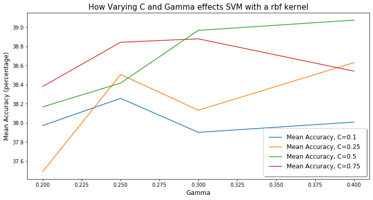

```
Optimum gamma for C=0.1 :  0.25
Optimum gamma for C=0.25 :  0.4
Optimum gamma for C=0.50 :  0.4
Optimum gamma for C=0.75 :  0.3
```

```python
#plots a scatter graph
plt.figure(figsize=(12, 6))
plt.plot(gammas,accuracy_mean_vector1r,label="Mean Accuracy, C=0.1")
plt.plot(gammas,accuracy_mean_vector2r,label="Mean Accuracy, C=0.25")
plt.plot(gammas,accuracy_mean_vector3r,label="Mean Accuracy, C=0.5")
plt.plot(gammas,accuracy_mean_vector4r,label="Mean Accuracy, C=0.75")
#labels axis
plt.xlabel('Gamma',size=12)
plt.ylabel('Mean Accuracy (percentage)',size=12)
#gives title
plt.title('How Varying C and Gamma effects SVM with a rbf kernel',size=15)
#gives legend
plt.legend(loc="lower right",fontsize=12,fancybox=True, framealpha=1, shadow=True, borderpad=1)
plt.show()
#code to find optimum gammas
print('Optimum gamma for C=0.1 : ',gammas[accuracy_mean_vector1r.index(max(accuracy_mean_vector1r))])
print('Optimum gamma for C=0.25 : ',gammas[accuracy_mean_vector2r.index(max(accuracy_mean_vector2r))])
print('Optimum gamma for C=0.50 : ',gammas[accuracy_mean_vector3r.index(max(accuracy_mean_vector3r))])
print('Optimum gamma for C=0.75 : ',gammas[accuracy_mean_vector4r.index(max(accuracy_mean_vector4r))])
```

### 2.4 Best SVM model

The best SVM model between the RBF kernel and Polynomial Kernel. The polynomial performs ever so slight better on the mean accuracy across the K-folds. This is unsurprising due to the nature of the problem, they describe the underlining data of the problem well since if the car is genrally in good condition it will have a good rating, but all features have to be relatively good to predict this. The polynomial and RBF kernel probably help the model capture this where as the linear kernel is basic and hence just not very good. The RBF and polynomial kernal models constantly change depnding on the shuffling of the the training data, but both generally perform on to the same accuracy of around 40%.

```python
#code to produce best SVM model
svc_best = svm.SVC(kernel='poly', degree=6,gamma=0.5,C=0.2)
svc_best.fit(train_clean_stand, train_rating_num)
```

```
SVC(C=0.2, cache_size=200, class_weight=None, coef0=0.0,
    decision_function_shape='ovr', degree=6, gamma=0.5, kernel='poly',
    max_iter=-1, probability=False, random_state=None, shrinking=True,
    tol=0.001, verbose=False)
```

## Neural networks

### 3.0 Basic Neural Network

The following code sets the basic attributes of our neural network

```python
#basic attrributes of neural netwrok
input_size = 6
hidden_size = 200
num_classes = 4
num_epochs = 120
batch_size = 64
learning_rate = 0.01
```

This Code prepares data for neural network format (it is stratified and balanced).

```python
# prepare data loading standised balanced data
X_train = torch.from_numpy(train_clean_stand.values).float()
y_train = torch.from_numpy(train_rating_num.values).float()
X_test = torch.from_numpy(test_clean_stand.values).float()
y_test = torch.from_numpy(test_rating_num.values).float()
```

This code splits the data into batches so model can be trained.

```python
# split data into batchs and into a form the neural network can understand
train0 = torch.utils.data.TensorDataset(X_train, y_train)
train_loader = torch.utils.data.DataLoader(train0, batch_size=batch_size,shuffle=True)
#does the same for test data
test0 = torch.utils.data.TensorDataset(X_test, y_test)
test_loader = torch.utils.data.DataLoader(test0, batch_size=batch_size)
```

This code a function which creates a neural network with 2 hidden layers, with inputable variables. e.g softmax it adds a softmax layer at output, but this generally reduces performance as corssentropy loss in thoery wants this for, but in practice it wants the normal layer output. So I have generally omitted softmax layer due to the decrease in convergence and performance.

```python
#function to produce neural network results train_data and test_data have to be data loader format.

def nenet(train_data,test_data,learning_rate=0.01,num_epochs=120,drop_out=0,Softmax=False):
  #important data has to be in train loader form
  train_loader=train_data
  #data u want to test put training data in if u want traing error
  test_loader=test_data
  ###########################
  #define our neural network#
  ###########################
  class NeuralNet(nn.Module):
      def __init__(self, input_size, hidden_size, num_classes,drop_out=0):
          super(NeuralNet, self).__init__()
          #first layer takes input data into 200 nodes in hidden layer
          self.fc1 = nn.Linear(input_size, hidden_size)
         #second hidden layer
          self.fc2 = nn.Linear(hidden_size, hidden_size)
        #drop out rate included default is =0 then drop out has no effect
          self.fc3 = nn.Dropout(p=drop_out, inplace=True)
        #output layer
          self.fc4 = nn.Linear(hidden_size, num_classes)

      def forward(self, x):
          out = F.relu(self.fc1(x))
          out = F.relu(self.fc2(out))
          out = self.fc3(out)
          out = self.fc4(out)
          #converts probabilties beteen 0 and 1 if softmax is set true
          if Softmax==True:
            out= F.softmax(out,dim=1)
          return out
  #defines our basic neural network object
  net = NeuralNet(6, 200, 4,drop_out)
  # loss
  criterion = nn.CrossEntropyLoss()

  # optimiser
  optimiser = torch.optim.SGD(net.parameters(), lr=learning_rate)

  #create loss array
  loss_values = []
  #create number of epochs array for graph purposes
  epocsarray=[]

  for epoch in range(num_epochs+1):

    ###################
    # train the model #
    ###################
    net.train()
    train_loss = 0.0
    #cpunt

    for i, (images, labels) in enumerate(train_loader, 0):

      # reshape images to long vector
      images = images.reshape(-1, 1*6)
      labels = labels.squeeze_().type(torch.LongTensor)

      # forward pass
      outputs = net(images)
      loss = criterion(outputs, labels)

      # backward and optimise
      optimiser.zero_grad()
      loss.backward()
      optimiser.step()

      # update loss
      train_loss += loss.item()


    loss_values.append(train_loss)
    epocsarray.append(epoch)

    ##################################
    # test the model on training data#
    ###################################
    net.eval()
    #reset correct and total
    correct = 0
    total = 0
    #interate through batches of train data
    for images, labels in train_loader:
      #reshape data appopriately
        images = images.reshape(-1, 1*6)
        labels = labels.squeeze_().type(torch.LongTensor)
        #predict dat
        outputs = net(images)
        #work index of max prob
        _, predicted = torch.max(outputs.data, 1)
        #number of labels
        total += labels.size(0)
        #number of correctly classified results
        correct += (predicted == labels).sum().item()
    train_acc=100 * correct / total
    #reset variables
    test_output=[]
    correct = 0
    total = 0
    for images, labels in test_loader:
      #reshape data appopriately
        images = images.reshape(-1, 1*6)
        labels = labels.squeeze_().type(torch.LongTensor)
        #predict dat
        outputs = net(images)
        #work index of max prob
        _, predicted = torch.max(outputs.data, 1)
        #prediction
        test_output.extend(list(predicted.numpy()))
        #number of labels
        total += labels.size(0)
        #number of correctly classified results
        correct += (predicted == labels).sum().item()
    test_acc=100 * correct / total
  return loss_values,epocsarray,train_acc,test_acc,test_output
```

### 3.1 How Learning rate effects convergence

The code below generates the data using the neural netwrok function above for different learning rates.

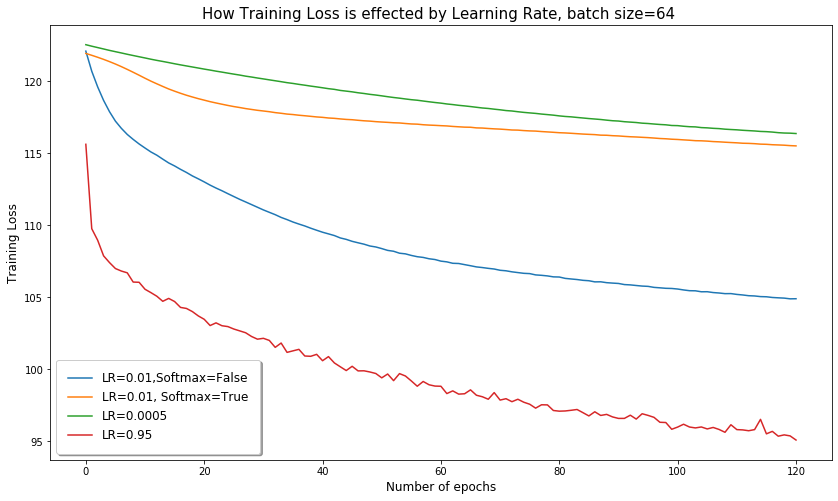

```
accuracy for L.R=0.005 42.90035587188612
accuracy for L.R=0.01 35.99644128113879
accuracy for L.R=0.95 50.05338078291815
```

```python
loss_values,epocsarray,train_acc,test_acc,test_output=nenet(train_loader,train_loader,0.01,120,0,Softmax=False)
loss_values1,epocsarray,train_acc1,test_acc1,test_output=nenet(train_loader,train_loader,0.01,120,0,Softmax=True)
loss_values2,epocsarray,train_acc2,test_acc2,test_output=nenet(train_loader,train_loader,0.0005,120,0,Softmax=False)
loss_values3,epocsarray,train_acc3,test_acc3,test_output=nenet(train_loader,train_loader,0.95,120,0,Softmax=False)
#plots a scatter graph
plt.figure(figsize=(14, 8))
plt.plot(epocsarray,loss_values,label="LR=0.01,Softmax=False")
plt.plot(epocsarray,loss_values1,label="LR=0.01, Softmax=True")
plt.plot(epocsarray,loss_values2,label="LR=0.0005")
plt.plot(epocsarray,loss_values3,label="LR=0.95")
#labels axis
plt.xlabel('Number of epochs',size=12)
plt.ylabel('Training Loss',size=12)
#gives title
plt.title('How Training Loss is effected by Learning Rate, batch size=64 ',size=15)
#gives legend
plt.legend(loc="lower left",fontsize=12,fancybox=True, framealpha=1, shadow=True, borderpad=1)
plt.show()
print('accuracy for L.R=0.005',test_acc)
print('accuracy for L.R=0.01',test_acc2)
print('accuracy for L.R=0.95',test_acc3)
```

### 3.2 Effects of Batch size

Code below genrates dat and plots graph for different batch sizes.

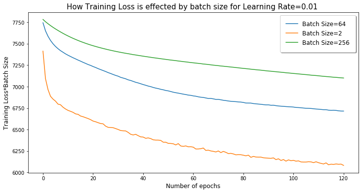

```
accuracy for batch size=64 42.829181494661924
accuracy for batch size=2 51.17437722419929
accuracy for batch size=256 37.79359430604982
```

```python
# split data into batchs and into a form the neural network can understand
train_loader_batch1 = torch.utils.data.DataLoader(train0, batch_size=batch_size,shuffle=True)
# split data into batchs and into a form the neural network can understand


#generate neural networks
loss_values,epocsarray,train_acc,test_acc,test_output=nenet(train_loader_batch1,train_loader_batch1,0.01,120,0)
loss_values2,epocsarray,train_acc2,test_acc2,test_output=nenet(train_loader_batch2,train_loader_batch2,0.01,120,0)
loss_values3,epocsarray,train_acc3,test_acc3,test_output=nenet(train_loader_batch3,train_loader_batch3,0.01,120,0)

#plots a scatter graph
plt.figure(figsize=(12, 6))
plt.plot(epocsarray,[x*64 for x in loss_values],label="Batch Size=64")
plt.plot(epocsarray,[x*2 for x in loss_values2],label="Batch Size=2")
plt.plot(epocsarray,[x*256 for x in loss_values3],label="Batch Size=256")
#labels axis
plt.xlabel('Number of epochs',size=12)
plt.ylabel('Training Loss*Batch Size',size=12)
#gives title
plt.title('How Training Loss is effected by batch size for Learning Rate=0.01 ',size=15)
#gives legend
plt.legend(loc="upper right",fontsize=12,fancybox=True, framealpha=1, shadow=True, borderpad=1)
plt.show()

#plots relevent varaibles
print('accuracy for batch size=64',test_acc)
print('accuracy for batch size=2',test_acc2)
print('accuracy for batch size=256',test_acc3)
```

As we can see for a very large batch size it does not converge very quickly, but does not overfit, but it is very computationally expensive. where as for small batch sizes it over fits which is shown by the noise on the orange line, although it does converge very quickly. Which is why a batch size of 64 gives us a happy medium of the 2 good converge rate and not over fitting.

### 3.3 Optimising dropout Rate

The following code optimises the for the drop outrate. Printing values of P it has been optimised over.

```python
batch_size=64
#set up accuracy vectors
accuracy_mean_vector_drop=[]
accuracy_max_vector_drop=[]
accuracy_min_vector_drop=[]
#values of dropout to be tested for
p=np.linspace(0,1,num=21)
print(p)
for i in range(len(p)):
  #reset accuracy vector
  accuracy=[]
  accuracy.clear()
  accuracy=[]
  #fit the model over folds
  for train_index, test_index in skf.split(train_clean_stand, train_rating_num):
     # split each fold into training and test
    X_train, X_test = train_clean_stand.iloc[train_index], train_clean_stand.iloc[test_index]
    Y_train, Y_test = train_rating_num.iloc[train_index], train_rating_num.iloc[test_index]
    # prepare data loading standised balanced data
    x_train = torch.from_numpy(X_train.values).float()
    y_train = torch.from_numpy(Y_train.values).float()
    x_test = torch.from_numpy(X_test.values).float()
    y_test = torch.from_numpy(Y_test.values).float()
    # split data into batchs and into a form the neural network can understand
    train0 = torch.utils.data.TensorDataset(x_train, y_train)
    train_loader = torch.utils.data.DataLoader(train0, batch_size=batch_size,shuffle=True)
    #does the same for test data
    test0 = torch.utils.data.TensorDataset(x_test, y_test)
    test_loader = torch.utils.data.DataLoader(test0, batch_size=batch_size)
    #make the model and train it
    loss_values,epocsarray,train_acc,test_acc,test_output=nenet(train_loader,test_loader,learning_rate=0.01,num_epochs=120,drop_out=p[i])
    #calculates mean accuracy percentage using inbuilt method
    accuracy.append(test_acc)
  accuracy_mean_vector_drop.append(np.mean(accuracy))
  accuracy_max_vector_drop.append(np.max(accuracy))
  accuracy_min_vector_drop.append(np.min(accuracy))
```

```
[0.   0.05 0.1  0.15 0.2  0.25 0.3  0.35 0.4  0.45 0.5  0.55 0.6  0.65
 0.7  0.75 0.8  0.85 0.9  0.95 1.  ]
```

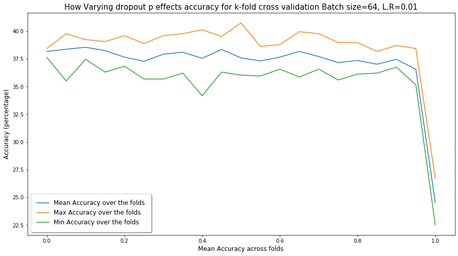

```
Optimum P 0.1
```

```python
#plots a scatter graph
plt.figure(figsize=(15, 8))
plt.plot(p,accuracy_mean_vector_drop,label="Mean Accuracy over the folds")
plt.plot(p,accuracy_max_vector_drop,label="Max Accuracy over the folds")
plt.plot(p,accuracy_min_vector_drop,label="Min Accuracy over the folds")
#labels axis
plt.xlabel('Mean Accuracy across folds',size=12)
plt.ylabel('Accuracy (percentage)',size=12)
#gives title
plt.title('How Varying dropout p effects accuracy for k-fold cross validation Batch size=64, L.R=0.01',size=15)
#gives legend
plt.legend(loc="lower left",fontsize=12,fancybox=True, framealpha=1, shadow=True, borderpad=1)
plt.show()

print('Optimum P',p[accuracy_mean_vector_drop.index(max(accuracy_mean_vector_drop))])
```

As we can see varying the drop out doesn't really improve the model very much. This is because dropout regulisation reduces over fitting, but in this situation overfitting is not a problem, hence why it only has minor improvemnt on the model. However a drop out of p=1 results in a random model effectively hence a result of 25% accuracy.

### 3.4 Best NN model

```python
#load training data and test data into NN form

# prepare data loading standised balanced data
X_train = torch.from_numpy(train_clean_stand.values).float()
y_train = torch.from_numpy(train_rating_num.values).float()
X_test = torch.from_numpy(test_clean_stand.values).float()
y_test = torch.from_numpy(test_rating_num.values).float()

# split data into batchs and into a form the neural network can understand
train0 = torch.utils.data.TensorDataset(X_train, y_train)
train_loader = torch.utils.data.DataLoader(train0, batch_size=batch_size,shuffle=True)
#does the same for test data
test0 = torch.utils.data.TensorDataset(X_test, y_test)
test_loader = torch.utils.data.DataLoader(test0, batch_size=batch_size)


#generate data of the model
loss_valuesnn,epocsarraynn,train_accnn,test_accnn,test_outputnn=nenet(train_loader,test_loader,learning_rate=0.01,num_epochs=200,drop_out=0.55)
```

## Discussions

### 4.1 Performance and results

Comparing how long it takes to fit and predict the various models, did do an average due to excessive run time of SVM

```python
#code to produce best SVM model
t1=time()
svc_best = svm.SVC(kernel='poly', degree=6,gamma=0.5,C=0.2)
svc_best.fit(train_clean_stand, train_rating_num)
svc_y=svc_best.predict(test_clean_stand)
t2=time()
#fit the best model
RFC_best = RandomForestClassifier(n_estimators=100, max_depth=8 ,random_state=0,max_features=4,bootstrap=True)
RFC_best.fit(train_clean_stand, train_rating_num)
rfc_y=RFC_best.predict(test_clean_stand)
t3=time()
#generate data of the model
loss_valuesnn,epocsarraynn,train_accnn,test_accnn,test_outputnn=nenet(train_loader,test_loader,learning_rate=0.01,num_epochs=200,drop_out=0.55)
t4=time()

print('time for best RFC=',t3-t2)
print('time for best SVC=',t2-t1)
print('time for Best Neural network=',t4-t3)
```

```
time for best RFC= 0.33419203758239746
time for best SVC= 81.96010303497314
time for Best Neural network= 43.457236528396606
```

As we can see RFC performs the best, then NN and then SVC.

Confusion Matrices for various models.

```
'              precision    recall  f1-score   support\n\n           0       0.62      0.90      0.73       282\n           1       0.36      0.40      0.38       171\n           2       0.48      0.41      0.44       237\n           3       0.63      0.39      0.49       302\n\n    accuracy        …
```

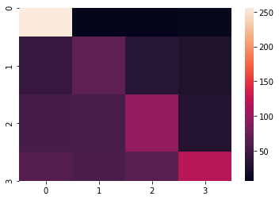

```python
#import relevant libraries
from sklearn.metrics import classification_report,confusion_matrix
import seaborn as sns
#code for RFC
sns.heatmap(confusion_matrix(rfc_y, test_rating_num))
classification_report(rfc_y, test_rating_num)
```

```
'              precision    recall  f1-score   support\n\n           0       0.62      0.80      0.70       318\n           1       0.31      0.29      0.30       200\n           2       0.32      0.34      0.33       197\n           3       0.48      0.32      0.39       277\n\n    accuracy        …
```

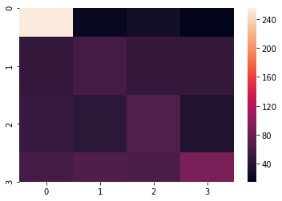

```python
#accuracy for SVM
sns.heatmap(confusion_matrix(svc_y, test_rating_num))
classification_report(svc_y, test_rating_num)
```

```python
#print model accuracys
print('rfc score',100*RFC_best.score(test_clean_stand, test_rating_num))
print('svm score',100*svc_best.score(test_clean_stand, test_rating_num))
print('rfc score',test_accnn)
```

```
rfc score 54.43548387096774
svm score 47.37903225806452
rfc score 37.72241992882562
```

As we can see they don't perform very well but RFC clearly has the best accuracy.

### 4.2 Suitabilty of the models

I don't believe any of the models are very good as they barely predict above 50% on the test data and even less on the training data which is strange. I belive this is mainly to do with the data itself we should probably do with different predictors. We could aslo do with far more data especially for NN, for example with drop out rate you need data over 2000 to get any useful results according to some papers. I would recommend my manager to use his own intution or gather more data and predictors. But I would RFC as it has highest accuracy on the test set and by far the quickest.

### 5.1&5.2 Neural Network with 5 hidden layers.

The code below is similar to the first function, you can choose whether it is has a relu activation function or a sigmodial, it also has 5 hidden layers. It also allows a softmax layer and dropout regulization to be included.

```python
#function to produce neural network results train_data and test_data have to be data loader format.

def nenetdeep(train_data,test_data,learning_rate=0.01,num_epochs=120,drop_out=0,Softmax=False,Sigmoid=False):
  #important data has to be in train loader form
  train_loader=train_data
  #data u want to test put training data in if u want traing error
  test_loader=test_data
  #make sure net is not an object which exists
  #del net
  #define our neural network
  if Sigmoid==False:
   #defines a neurel net with 5 hidden layer
     class NeuralNetdeep(nn.Module):
        def __init__(self, input_size, hidden_size, num_classes,drop_out=0):
          super(NeuralNetdeep, self).__init__()
          #first layer takes input data into #hidden_size nodes in hidden layer
          self.fc1 = nn.Linear(input_size, hidden_size)
          #2nd hidden layer
          self.fc2 = nn.Linear(hidden_size, hidden_size)
          #drop out rate included default is =0 then drop out has no effect
          self.fc3 = nn.Dropout(p=drop_out, inplace=True)
          # 3 hidden layers
          self.fc4 = nn.Linear(hidden_size, hidden_size)
          self.fc5 = nn.Linear(hidden_size, hidden_size)
          self.fc6 = nn.Linear(hidden_size, hidden_size)
          #ouput
          self.fc7 = nn.Linear(hidden_size, num_classes)
        def forward(self, x):
          #uses relu activation
          out = F.relu(self.fc1(x))
          out = F.relu(self.fc2(out))
          out = self.fc3(out)
          out = F.relu(self.fc4(out))
          out = F.relu(self.fc5(out))
          out = F.relu(self.fc6(out))
          out = self.fc7(out)
          #converts probabilties beteen 0 and 1
          if Softmax==True:
             out= F.softmax(out,dim=1)
          return out
          #defines a neurel net for a sigmoid activation unit
  else:
      class NeuralNetdeep(nn.Module):
        def __init__(self, input_size, hidden_size, num_classes,drop_out=0):
          super(NeuralNetdeep, self).__init__()
          #first layer takes input data into #hidden_size nodes in hidden layer
          self.fc1 = nn.Linear(input_size, hidden_size)
          #2nd hidden layer
          self.fc2 = nn.Linear(hidden_size, hidden_size)
          #drop out rate included default is =0 then drop out has no effect
          self.fc3 = nn.Dropout(p=drop_out, inplace=True)
          # 3 hidden layers
          self.fc4 = nn.Linear(hidden_size, hidden_size)
          self.fc5 = nn.Linear(hidden_size, hidden_size)
          self.fc6 = nn.Linear(hidden_size, hidden_size)
          #ouput
          self.fc7 = nn.Linear(hidden_size, num_classes)

        #define forward pass
        def forward(self, x):
          out = torch.sigmoid(self.fc1(x))
          out = torch.sigmoid(self.fc2(out))
          out = self.fc3(out)
          out = torch.sigmoid(self.fc4(out))
          out = torch.sigmoid(self.fc5(out))
          out = torch.sigmoid(self.fc6(out))
          out = self.fc7(out)
          if Softmax==True:
            out= F.softmax(out,dim=1)
          return out

  #creates our neural network object 80 neurons in each layer
  net = NeuralNetdeep(6, 80, 4,drop_out)
  # loss
  criterion = nn.CrossEntropyLoss()

  # optimiser
  optimiser = torch.optim.SGD(net.parameters(), lr=learning_rate)

  #create loss array
  loss_values = []
  #create number of epochs array for graph purposes
  epocsarray=[]

  for epoch in range(num_epochs+1):

    ###################
    # train the model #
    ###################
    net.train()
    train_loss = 0.0
    #cpunt

    for i, (images, labels) in enumerate(train_loader, 0):

      # reshape images to long vector
      images = images.reshape(-1, 1*6)
      labels = labels.squeeze_().type(torch.LongTensor)

      # forward pass
      outputs = net(images)
      loss = criterion(outputs, labels)

      # backward and optimise
      optimiser.zero_grad()
      loss.backward()
      optimiser.step()

      # update loss
      train_loss += loss.item()


    loss_values.append(train_loss)
    epocsarray.append(epoch)

    ##################################
    # test the model on training data#
    ###################################
    net.eval()
    #reset correct and total
    correct = 0
    total = 0
    #interate through batches of train data
    for images, labels in train_loader:
      #reshape data appopriately
        images = images.reshape(-1, 1*6)
        labels = labels.squeeze_().type(torch.LongTensor)
        #predict dat
        outputs = net(images)
        #work index of max prob
        _, predicted = torch.max(outputs.data, 1)
        #number of labels
        total += labels.size(0)
        #number of correctly classified results
        correct += (predicted == labels).sum().item()
    train_acc=100 * correct / total
    #reset variables
    test_output=[]
    correct = 0
    total = 0
    for images, labels in test_loader:
      #reshape data appopriately
        images = images.reshape(-1, 1*6)
        labels = labels.squeeze_().type(torch.LongTensor)
        #predict dat
        outputs = net(images)
        #work index of max prob
        _, predicted = torch.max(outputs.data, 1)
        #actual predcition
        test_output.extend(list(predicted.numpy()))
        #number of labels
        total += labels.size(0)
        #number of correctly classified results
        correct += (predicted == labels).sum().item()
    test_acc=100 * correct / total
  return loss_values,epocsarray,train_acc,test_acc,test_output
```

We now compare performance of the networks, using the above functions to generating the data and timing it.

```python
# split data into batchs and into a form the neural network can understand
train0 = torch.utils.data.TensorDataset(X_train, y_train)
train_loader = torch.utils.data.DataLoader(train0, batch_size=batch_size,shuffle=True)
#does the same for test data
test0 = torch.utils.data.TensorDataset(X_test, y_test)
test_loader = torch.utils.data.DataLoader(test0, batch_size=64)

t0=time()
loss_values1,epocsarray,train_acc1,test_acc1,test_output=nenet(train_loader,test_loader,0.01,120,0,Softmax=True)
t1=time()
loss_values2,epocsarray,train_acc2,test_acc2,test_output=nenetdeep(train_loader,test_loader,learning_rate=0.01,num_epochs=120,drop_out=0,Softmax=True,Sigmoid=False)
t2=time()
loss_values3,epocsarray,train_acc3,test_acc3,test_output=nenetdeep(train_loader,test_loader,learning_rate=0.01,num_epochs=120,drop_out=0,Softmax=True,Sigmoid=True)
t3=time()

print('runtime for shallow neural network Relu Activation:',t1-t0)
print('runtime for deep neural network Relu Activation:' ,t2-t1)
print('runtime for deep neural network Sigmodial activation',t3-t2)
```

```
runtime for shallow neural network Relu Activation: 31.884454250335693
runtime for deep neural network Relu Activation: 34.5891478061676
runtime for deep neural network Sigmodial activation 36.20143795013428
```

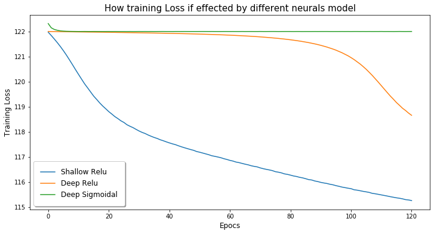

```
Training and Test Accuracy for shallow neural network Relu Activation: 39.35943060498221 51.71370967741935
Training and Test for deep neural network Relu Activation: 33.70106761565836 48.185483870967744
Training and Test for deep neural network Sigmodial activation 25.0 20.56451612903226
```

```python
#plots a scatter graph
plt.figure(figsize=(12, 6))
plt.plot(epocsarray,loss_values1,label="Shallow Relu")
plt.plot(epocsarray,loss_values2,label="Deep Relu")
plt.plot(epocsarray,loss_values3,label="Deep Sigmoidal")
#labels axis
plt.xlabel('Epocs',size=12)
plt.ylabel('Training Loss',size=12)
#gives title
plt.title('How training Loss if effected by different neurals model',size=15)
#gives legend
plt.legend(loc="lower left",fontsize=12,fancybox=True, framealpha=1, shadow=True, borderpad=1)
plt.show()


print('Training and Test Accuracy for shallow neural network Relu Activation:',train_acc1,test_acc1)
print('Training and Test for deep neural network Relu Activation:' ,train_acc2,test_acc2)
print('Training and Test for deep neural network Sigmodial activation',train_acc3,test_acc3)
```

The Shallow Network appears to be performing the best accuracys and timings and the best converging Training loss. Deep Sigmoid appear to perform the worst and is even worse then just taking a random guess. This is becuase it has to many layers for the sigmoid to be effective. It also has very poor rate of convergence. The sigmoid is bounded wheres as the relu is not and relu is always zero for values less then zero.